# Analiza składu jeziora

## 12. Macierz ITS

### 12.1 Tworzenie kombinacji wag

```r
x <- c(0, 1)
wynik <- expand.grid(rep(list(x), 8))

mnoznik <- data.frame(wynik)
```

### 12.2 Tworzenie macierzy

```r
i = 56
model1 = lm(ITS~.,data = dane[,c(mnoznik[i,1]*1,
                                 mnoznik[i,2]*2,
                                 mnoznik[i,3]*3,
                                 mnoznik[i,4]*4,
                                 mnoznik[i,5]*5,
                                 mnoznik[i,6]*6,
                                 mnoznik[i,7]*7,8)])
pre1 = as.data.frame(predict(model1))
pre1
```

```
   predict(model1)
1         7.667101
2         7.790495
3         8.128190
4         7.887680
5         8.170464
6         8.198759
7         7.803403
8         7.928329
9         8.147337
10        8.083205
11        7.865983
12        8.092176
13        8.492469
14        8.450919
```

[output cut: 37 more lines]

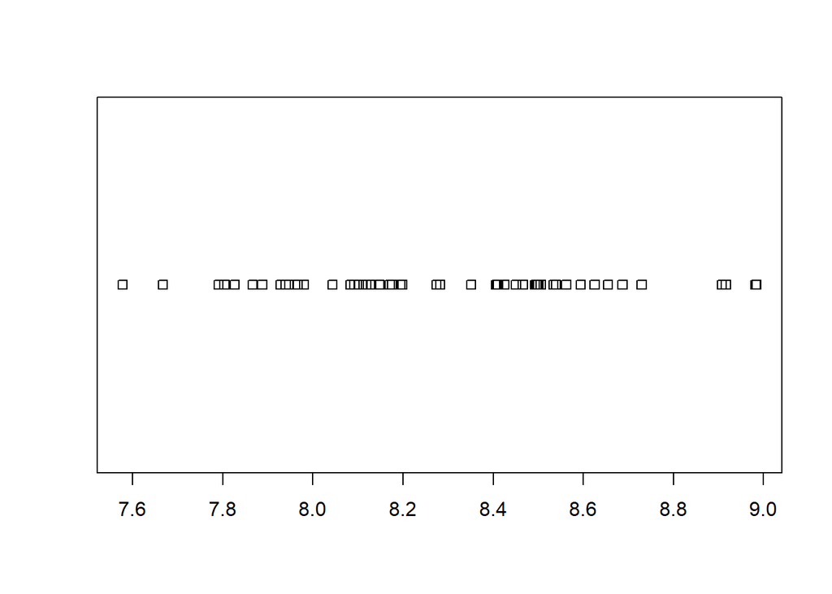

```r
plot(pre1)
points(dane$ITS, col = "orange")
```

### 12.3 Tworzenie modeli dla różnych kombinacji wag

```r
# Przygotowanie pustej ramki danych na wyniki predykcji
wyniki_predykcji <- data.frame(matrix(nrow = nrow(dane), ncol = 256))

for (i in 1:256) {
  # Dodanie modyfikowanych zmiennych z wagami mnoznik[i, ]
  dane$modyfikacja <- mnoznik[i, 1] * dane$chla +
    mnoznik[i, 2] * dane$temp +
    mnoznik[i, 3] * dane$bar +
    mnoznik[i, 4] * dane$nas +
    mnoznik[i, 5] * dane$przew +
    mnoznik[i, 6] * dane$ph +
    mnoznik[i, 7] * dane$namon

  # Tworzenie modelu regresji
  model <- lm(ITS ~ modyfikacja, data = dane)

  # Obliczanie predykcji dla wszystkich wierszy
  predykcja <- predict(model, newdata = dane)

  # Dodanie wyników predykcji do odpowiedniej kolumny
  wyniki_predykcji[, i] <- predykcja
}



# Dodanie nazw kolumn (np. Model_1, Model_2, ..., Model_256)
colnames(wyniki_predykcji) <- paste0("Model_", 1:256)

# Podgląd wyników
head(wyniki_predykcji)
```

```
   Model_1  Model_2  Model_3  Model_4  Model_5  Model_6  Model_7  Model_8
1 8.293766 8.133086 8.156197 8.092476 8.280171 8.104316 8.238384 8.069886
2 8.293766 8.143978 8.267232 8.130091 8.298180 8.180900 8.301877 8.171506
3 8.293766 8.191440 8.399086 8.211044 8.271166 8.121111 8.248004 8.136009
4 8.293766 8.142422 8.416435 8.163617 8.280171 8.112377 8.274460 8.130441
5 8.293766 8.182881 8.156197 8.144810 8.262161 8.080131 8.190283 8.044829
6 8.293766 8.204667 8.485832 8.245388 8.271166 8.132531 8.260030 8.165242
   Model_9 Model_10 Model_11 Model_12 Model_13 Model_14 Model_15 Model_16
1 8.015120 8.021055 7.963284 7.991216 8.017742 7.993786 7.980503 7.967910
2 8.146754 8.092182 8.138637 8.085206 8.215434 8.123241 8.208586 8.118044
3 8.114511 8.119252 8.162114 8.138954 8.035733 8.052583 8.070498 8.071534
4 8.055350 8.048125 8.111392 8.070724 8.046193 8.018784 8.085978 8.040869
5 8.422149 8.255292 8.362103 8.227374 8.200999 8.146326 8.161318 8.120727
6 8.213014 8.176983 8.294860 8.214563 8.105396 8.105895 8.165033 8.140916
  Model_17 Model_18 Model_19 Model_20 Model_21 Model_22 Model_23 Model_24
```

[output cut: 230 more lines]

### 12.4 Tworzenie heatmapy

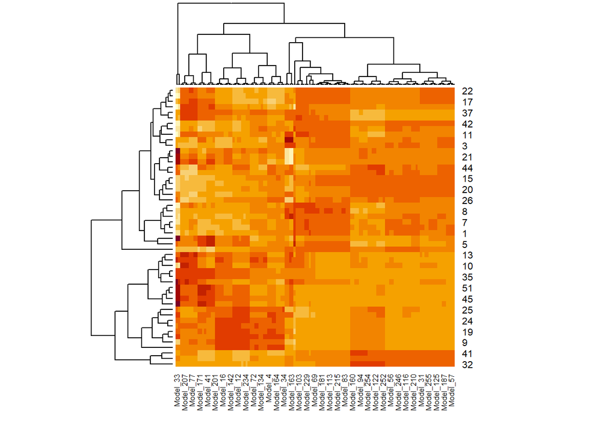

```r
# Konwersja wszystkich wartości w ramce danych na liczby (jeśli to możliwe)
wyniki_predykcji[] <- lapply(wyniki_predykcji, as.numeric)

# Ponownie konwertujemy na macierz
wyniki_predykcji_matrix <- as.matrix(wyniki_predykcji)

# Generowanie heatmap

heatmap(wyniki_predykcji_matrix)
```

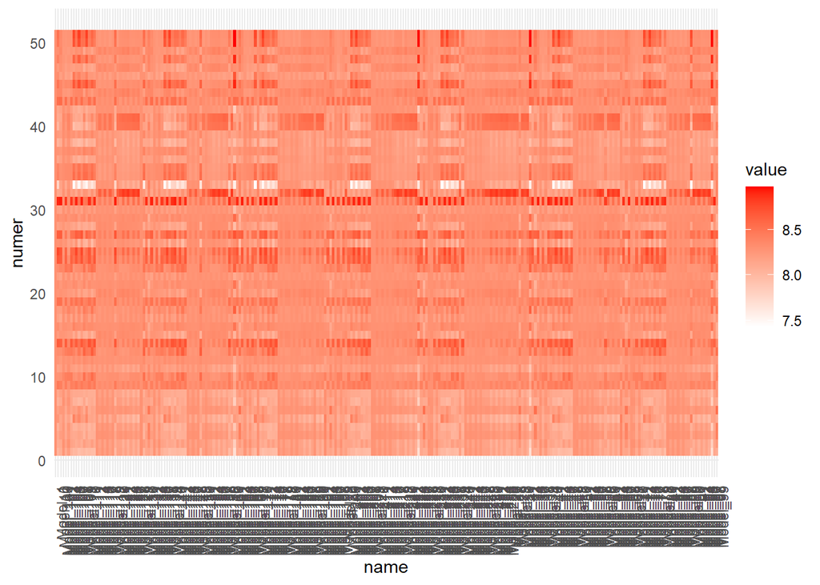

```r
wyniki_predykcji$numer = 1:51

wlong=wyniki_predykcji %>%
  pivot_longer(c(1:256))


ggplot(data = wlong, aes(x = name, y = numer, fill = value)) +
  geom_tile() +
  scale_fill_gradient(low = "white", high = "red") +
  theme_minimal() +
  theme(axis.text.x = element_text(angle = 90, hjust = 1))
```

## 13 Ocena dopasowania modeli hydrologicznych

### 13.1 Obliczenie metryk dopasowania modelu

```r
# Obliczenie wartości przewidywanych
predicted <- predict(model)

# Rzeczywiste wartości
observed <- dane$ITS

# NSE (Nash-Sutcliffe Efficiency)
nse_value <- NSE(predicted, observed)

# RMSE
rmse_value <- rmse(predicted, observed)

# MAE
mae_value <- mae(predicted, observed)

# Wyświetlenie wyników
cat("NSE:", nse_value, "\nRMSE:", rmse_value, "\nMAE:", mae_value)
```

```
NSE: 0.196978
RMSE: 0.3155636
MAE: 0.2563924
```

**Wyniki metryk dopasowania modelu:** NSE (Nash-Sutcliffe Efficiency): 0.196978

NSE w zakresie od 0 do 1 wskazuje na jakość dopasowania modelu do danych. Wartość 0.2 sugeruje, że model nie przewiduje dobrze zmiennej zależnej (ITS). Wynik jest niski, co oznacza, że model tylko minimalnie lepiej opisuje dane niż prosta średnia wartości rzeczywistych. RMSE (Root Mean Square Error): 0.3155636

RMSE mierzy średnią różnicę między wartościami rzeczywistymi a przewidywanymi. Im niższa wartość, tym lepsze dopasowanie modelu. RMSE w tym przypadku wskazuje na umiarkowaną różnicę między wartościami przewidywanymi a rzeczywistymi. MAE (Mean Absolute Error): 0.2563924

MAE mierzy przeciętny błąd bezwzględny między rzeczywistymi a przewidywanymi wartościami. Podobnie jak RMSE, im niższa wartość, tym lepsze dopasowanie. MAE pokazuje, że średni błąd w przewidywaniach wynosi około 0.26 jednostki.